# Transformações e Suavizações

## Introdução

- As vezes os dados precisam ser transformados para a utilização de determinados métodos/modelos;
- O objetivo é tornar os modelos mais simples, no caso das ST o objetivo seria melhorar as previsões;
- As transformações devem ser feitas exclusivamente para aplicação do modelo, e não como uma técnica de analise dos dados em si.

### Alguns exemplos de transfomação dos dados em ST:

- **Utilização de funções:** Logarítmicas, Potências, Exponenciais, ou transformação *Box-Cox*
- **Diferenciação:** Series não estacionárias, objetivo é transformar a série em estacionária (ex: log), estabilizando a média.
- **Box-Cox:** Estabiliza a variância.
- **Médias Móveis:** Permite a suavização dos dados da ST. Reduz outliers e os efeitos sazonais
- **Outras técnicas mais avançadas de suavização:** Kernel, Loess, Splines e *Generalized Additive Model* (GAM)

Para mostrar o resultado dessas transformações, iremos mostrar algumas técnicas.

### Transformações Box-Cox, Digferenciação e Logarítmica

- Box and Cox (1964) propuseram uma transformação na variável da ST $Z_t$, que depende do parâmetro $\lambda$ da seguinte forma:

$$Z_{t}(\lambda) = \left\{ \begin{array}{rc} Z_t^{\lambda}, &\mbox{se} \quad \lambda \neq 0, \\ ln(Z_t) , &\mbox{se} \quad \lambda = 0. \end{array}\right.$$

Se o valor de $\lambda$ é igual a zero, a transformação logarítmica da sequência inicial é realizada, no caso em que o valor de lambda difere de zero, a transformação é por lei exponencial. Quando $\lambda$ é igual a 1, a série é analisada em sua escala original, enquanto o caso $\lambda = 1/2$ corresponde à transformação transformação da raiz quadrada. Para que a transformação seja aplicável, a série deve ser estritamente positiva.

Ex: Utilizando os dados do dataset Air Passengers, temos:

[figure not shown]

```r
library(forecast)
par(mfrow=c(3,2))
# Série original
plot(AirPassengers, ylab="Passageiros", main="Original")
# Lambda = 0, Logaritmica
t1 <- BoxCox(AirPassengers,lambda =0 )
plot(t1, ylab="Passageiros", main="Lambda = 0, Logaritmica")
# Lambda = 0.34
t2 <- BoxCox(AirPassengers,lambda =.1 )
plot(t2, ylab="Passageiros", main="Lambda = 0.34")
# Gera labda automático
lbd <- BoxCox.lambda(AirPassengers)
# print(lbd)
t3 <- BoxCox(AirPassengers,lambda =lbd )
plot(t3, ylab="Passageiros", main="Labda Automático")
# Diferenciacao
t4 <- diff(AirPassengers)
plot(t4, ylab="Passageiros", main="Diferenciacao")
# Logaritmo
t5 <- log(AirPassengers)
plot(t5, ylab="Passageiros", main="Log")
```

## Métodos de Alisamento ou Suavização

- Uma função é suave se contı́nua e derivável em todos os pontos.
- Utiliza-se a expressão Funções de Suavização para definir funções que aplicadas sobre um conjunto numérico retornam outro conjunto cujos valores tendem à média, local ou global.
- Utiliza-se funções de suavização quando se supõe que o fenômeno é de fato suave, e as observações apresentam variabilidade aleatória pouco relevante.
- Também são utilizadas quando se deseja modelar a estrutura geral o fenômeno, desconsiderando cada ocorência isolada.

### Algumas funções de suavização

Existem diversas funções de suavização no **R** dentre as principais destacamos:

1. **Médias móveis:** O métodos mais simples de suavização.
2. **Kernel density:** Estimativa de densidade de probabilidade – equivale à uma média ponderada.
3. **Loess/Lowess:** locally weighted scatterplot smoothing – estende a mesma idéia, mas os valores entram em uma regressao ponderada (não apenas média, ou seja, inclui uma inclinação)
4. **Splines:** cúbica, p-splines, thin plate
- Todas essas funções podem ser uni ou multi-dimensionais, existem ainda outras funções para suavizar

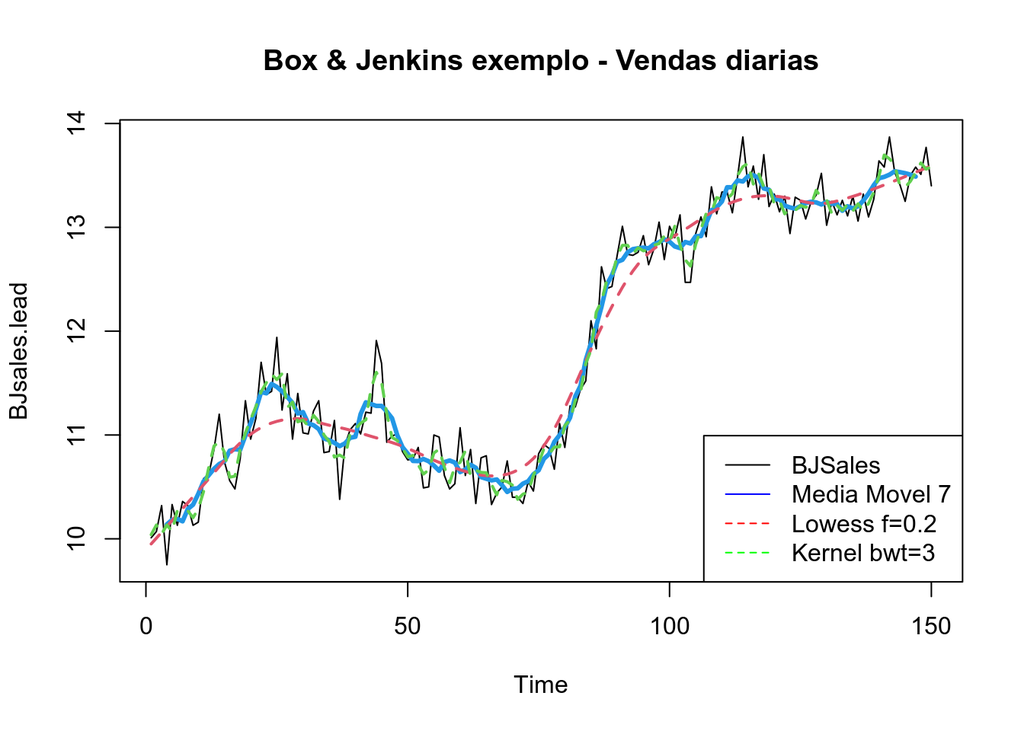

### Médias móveis

Considere a ST estacionária e localmente constante, composta de seu nível e mais um ruído aleatório.

$$Z_t = \mu_t + a_t ,$$
$$t = 1,2,...,N$$

Sendo $E(a_t) = 0$, $Var(a_t)=\sigma^2_a$ e $\mu_t$ é um parâmetro desconhecido que varia com o tempo.

A técnica de média móvel consistew em calcular a média aritmética das $h$ observcações mais recentes, ou seja,

$$M_t = \dfrac{Z_t+Z_{t-1}+...+Z_{t-h+1}}{h}$$

- Denotamos por $h$ sendo o comprimento da média.
- Desta forma, $M_t$ é uma estimativa do nível $\mu_t$ que não leva em consideração as observações mais antigas. Note que a cada período a observação mais antiga é substituída pela mais recente, calculando-se uma média nova.

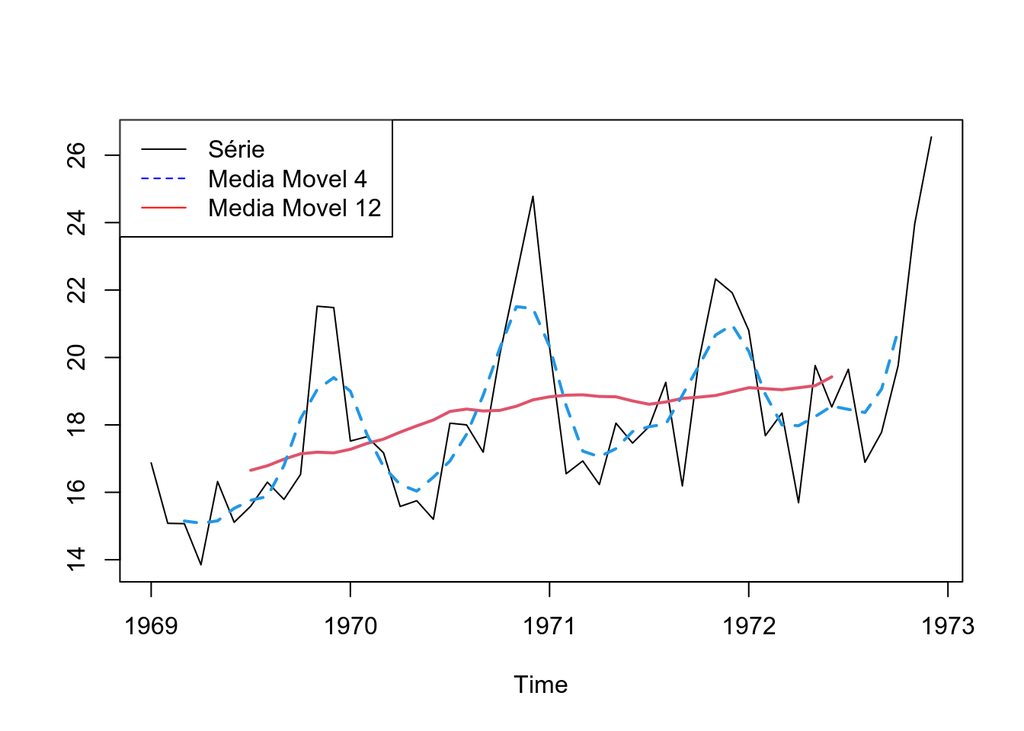

Série original , vamos exemplificar o que acontece com quando se usa uma janela de 3 meses, repare as 3 primeiras observações

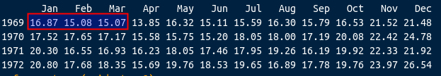

Serie com Media Móvel 3 , note que o primeiro é ultimo valores da serie agora são **NA**

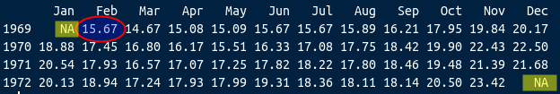

Observe que o valor para fevereiro e calculado a partir dos 3 primeiros valores

```
(16.87 + 15.08 + 15.07)/3 =  15.67
```

**Exemplo:** Utilizando a ST mensal referente as mortes em estradas Reino Unido (1969–1984), temos:

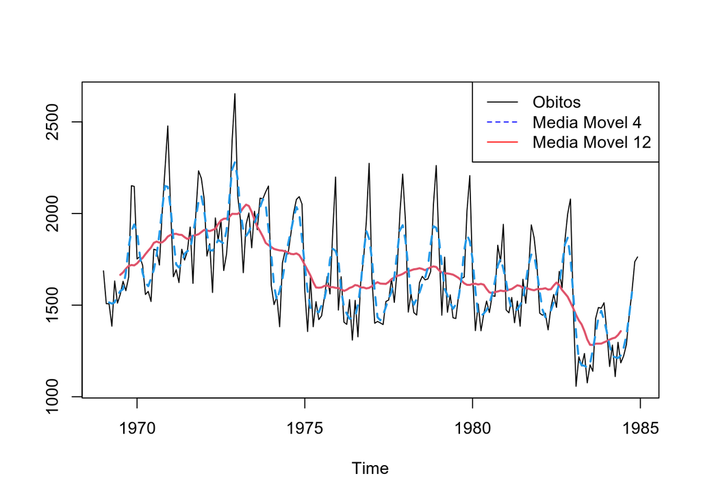

```r
library(forecast)
plot(UKDriverDeaths,ylab='')
lines(ma(UKDriverDeaths,12),col=2,lty=1,lwd=2)
lines(ma(UKDriverDeaths,4),col=4,lty=2,lwd=2)
legend("topright",legend=c("Obitos","Media Movel 4","Media Movel 12"),
       col = c("black",'blue','red'), lty=c(1,2,1), cex=1)
```

### Utilização das Médias Móveis

- Processo de Transformação - “Suavização da Série”
- Remoção de outliers
- Identificação de tendências

## Kernel

O algoritmo:

- Seja $(x)$ ponto para o qual se deseja estimar f(.)
- Defina a função **kernel**: simétrica, unimodal, centrada em $(x)$, que cai a zero nos limites da **vizinhança**.
- Esse subconjunto dos dados, também denominado ou ou parâmetro de suavização controla flexibilidade do kernel.
- Repita o procedimento para diversos $(x)$ conecte os pontos

$$\hat{f_h}(x) = \dfrac{1}{Nh}\sum{K \left( \dfrac{x-x_i}{h}\right)}$$

- $h$ $\rightarrow$ largura de banda
- $K$ $\rightarrow$ função de suavização

Kernel Gaussiano:
$$k(x)=\dfrac{1}{\sqrt{2\pi}} exp(1/2 x^2)$$

### Diferentes Funções Kernel

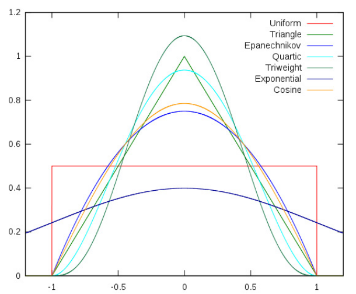

Vamos a uma demostração:

```r
library(tcltk)
demo("tkdensity")
```

ao chamar a função *demo()* você vai ver um painel de controle como o abaixo

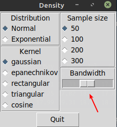

e uma gráfico de uma função **kernel** como abaixo. ultilise o controle deslisante mostrado pela seta e altere as opções.

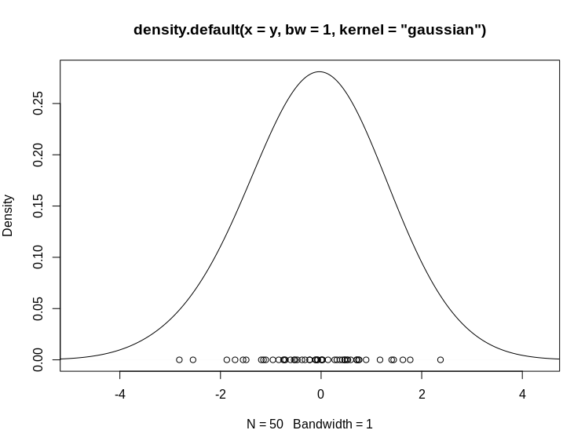

- Série Temporal: Leptospirose *vs* Clima

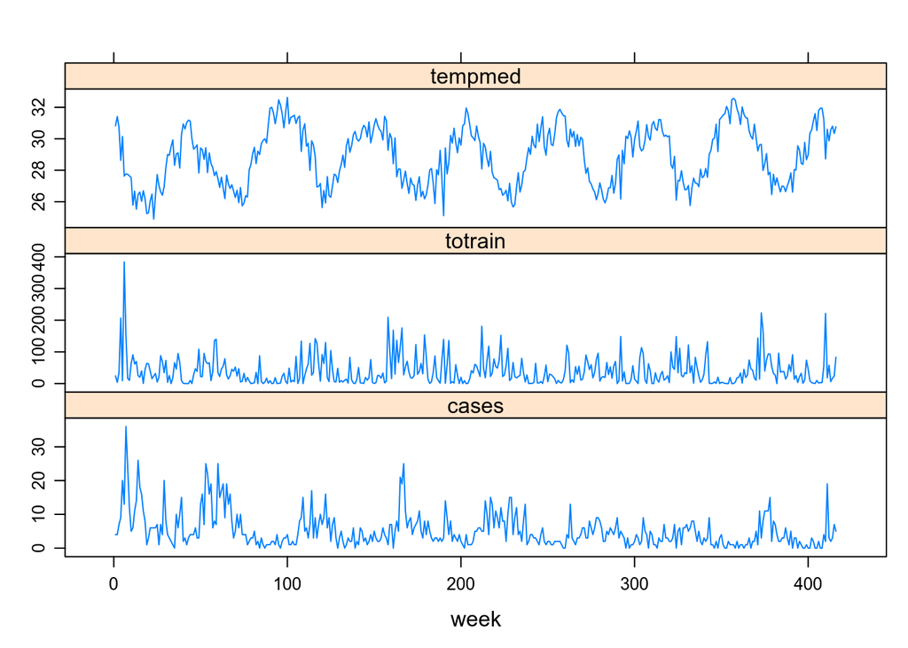

```r
#declara local na internet onde estão os dados
local <- "https://gitlab.procc.fiocruz.br/oswaldo/eco2019/raw/master/dados/"


## a função paste0 junta o local e o nome do arquivo!
lepto <- read.csv2(paste0(local,"leptoruido.csv"), header=T)
dia <- read.table(paste0(local,"climadia.dat"), header=T)

library(lattice)
library(car)
library(sm)
library(survival)

#XY condicionado
xyplot(cases + totrain + tempmed ~ week,
 outer=TRUE, layout=c(1, 3), pch=1, type="l",ylab="",
  scales=list(x=list(relation='same'), y=list(relation='free')),
 data=lepto)
```

- Exemplos de Kernel

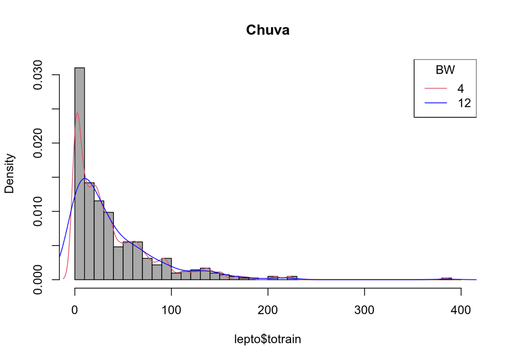

```r
#### density - default "gaussian"
hist(lepto$totrain, breaks=seq(0,400,by=10),freq=F, col="darkgray", main = "Chuva")
lines(density(lepto$totrain , 4),col=2)
lines(density(lepto$totrain , 12),col="blue")
legend("topright", c("4","12"), title="BW", col=c(2,"blue"), lty=c(1,1))
```

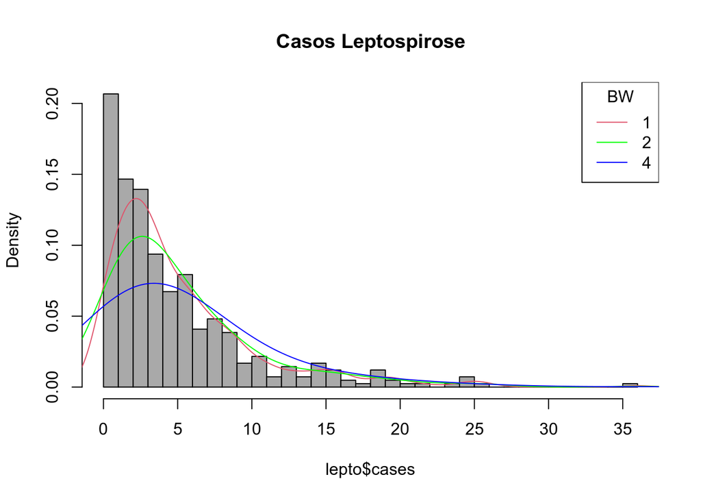

```r
hist(lepto$cases, breaks=seq(0,36,by=1),freq=F, col="darkgray", main = "Casos Leptospirose")
lines(density(lepto$cases , 1),col=2)
lines(density(lepto$cases , 2),col="green")
lines(density(lepto$cases , 4),col="blue")
legend("topright", c("1","2","4"), title="BW", col=c(2,"green","blue"), lty=c(1,1,1))
```

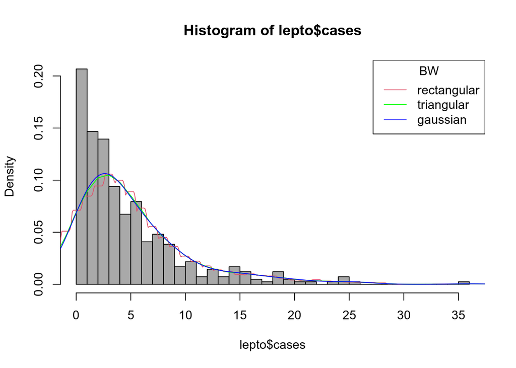

```r
hist(lepto$cases, breaks=seq(0,36,by=1),freq=F, col="darkgray")
lines(density(lepto$cases , 2, kernel = "rectangular" ),col=2)
lines(density(lepto$cases , 2, kernel = "triangular" ),col="green")
lines(density(lepto$cases , 2, kernel = "gaussian" ),col="blue")
legend("topright", c("rectangular","triangular","gaussian"), title="BW", col=c(2,"green","blue"), lty=c(1,1,1))
```

- Aplicando o Kernel em ST

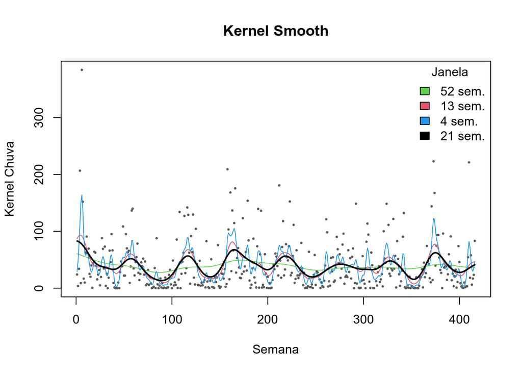

```r
plot(totrain ~ week, data=lepto, cex=.3, pch=19,col="gray35",ylab="Kernel Chuva", xlab="Semana",
  main="Kernel Smooth")
lines(ksmooth(lepto$week, lepto$totrain, kernel = "normal", bandwidth = 52), col=3)
lines(ksmooth(lepto$week, lepto$totrain, kernel = "normal", bandwidth = 13), col=2)
lines(ksmooth(lepto$week, lepto$totrain, kernel = "normal",  bandwidth = 4), col=4)
lines(ksmooth(lepto$week, lepto$totrain, kernel = "normal", bandwidth = 21), lwd=2)
legend("topright",c("52 sem.","13 sem.","4 sem.","21 sem."),fill=c(3,2,4,1), title="Janela",bty="n")
```

### Largura de Banda

Como estimar a largura de banda ?

- Validação cruzada

$$CV(\lambda) = \frac{1}{n} \sum_{j=1}^n \left( y_i - \hat{f}_{\lambda(j)} (x_j) \right) ^2$$

- O ponto deixado fora do ajuste a cada vez,
- $\lambda$ o valor que minimiza essa equação.

```r
### efeito de borda
# exluindo os pontos 1 a 3 para forcar borda
lepto2 <- lepto[-c(1,2,3),]

hcv(lepto2$week, lepto2$totrain, display="lines")
```

[1] 6.129

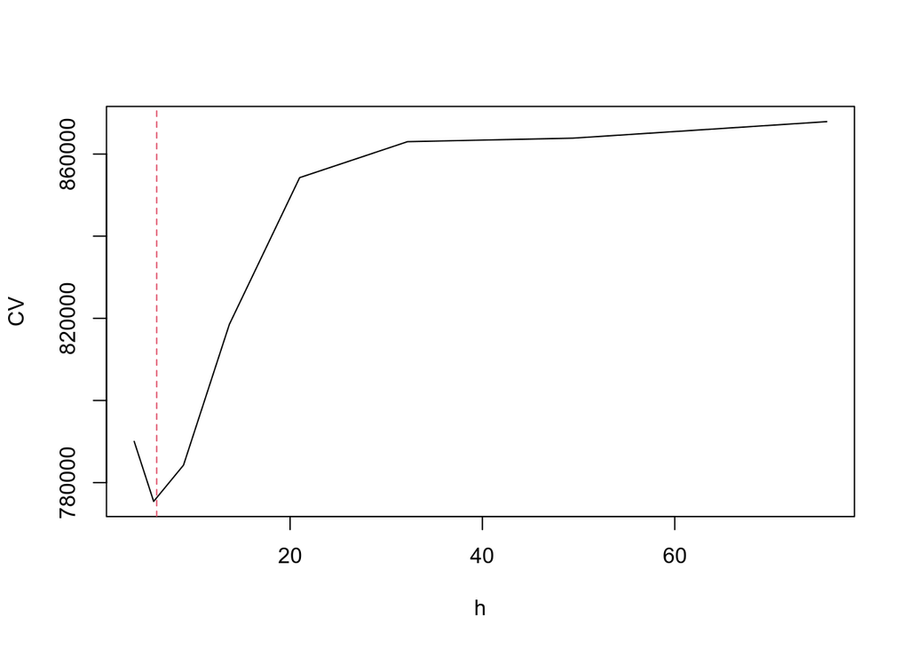

```r
abline(v= 6.129356, col=2,lty=2)
```

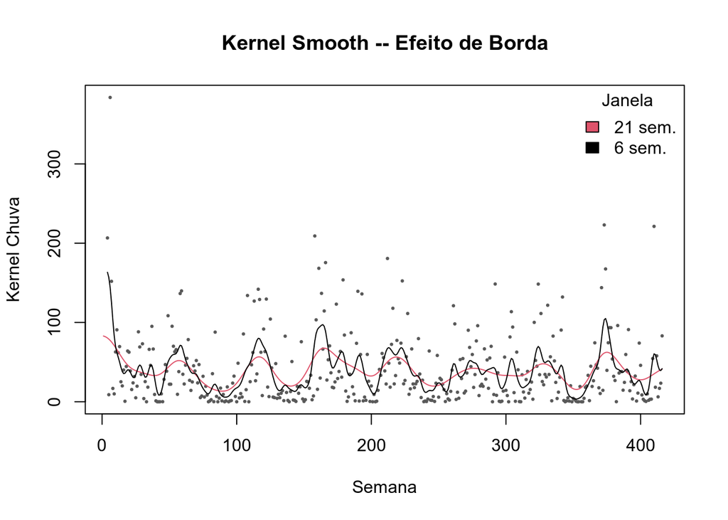

```r
plot(totrain ~ week, data=lepto2, cex=.3, pch=19,col="gray35",ylab="Kernel Chuva", xlab="Semana",
  main="Kernel Smooth -- Efeito de Borda")
lines(ksmooth(lepto$week, lepto$totrain, kernel = "normal", bandwidth = 21 ), col=2)
lines(ksmooth(lepto2$week, lepto2$totrain, kernel = "normal", bandwidth = 6.1 ), col=1)
legend("topright",c("21 sem.","6 sem."),fill=c(2,1), title="Janela",bty="n")
```

### Utilização do Kernel

- Vantagens: simples, ótimo para análise exploratória.
- Desvantagens: efeito de borda.
- Muito sensı́vel à largura de banda.
- Escolha automática de largura de banda pode não ser o desejável.
- Pouco sensı́vel à forma da função, desde que suave.

## Lowess (Locally Weighted Sum of Square)

- Semelhante ao kernel, mas os valores são estimados a partir de uma regressão local ao invés da média ponderada.
- A cada ponto do conjunto de dados um polinômio é ajustado utilizando um sub-conjunto através de mı́nimos quadrados ponderados de forma a dar maior peso aos pontos próximos.
- O subconjunto dos dados é também denominado janela ou largura de banda ou parâmetro de suavização e controla flexibilidade da função de regressão – se a janela for igual ao total de pontos fica igual à regressão.
- Quanto maior o tamanho da janela, maior o alisamento e vice-versa.
- O grau do polinômio de cada regressão local em geral é baixo. Polinômio de primeiro grau é a regressão linear local; de segundo regressão quadrática.
- A largura da janela é indicado por uma fração dos dados que varia de 0 a 1.
  - Exemplo: largura 0,1 significa que a janela tem largura que equivale a 10% do eixo horizontal;
  - Polinômio de grau 0 é a média móvel;
  - Se a janela for de 100% dos pontos = média.

Existem varias funções que implementam o *Lowess* no R temos dois grupos que implementa uma função de suavização como por exemplo a *lowess()* ou como modelo *loess()* .

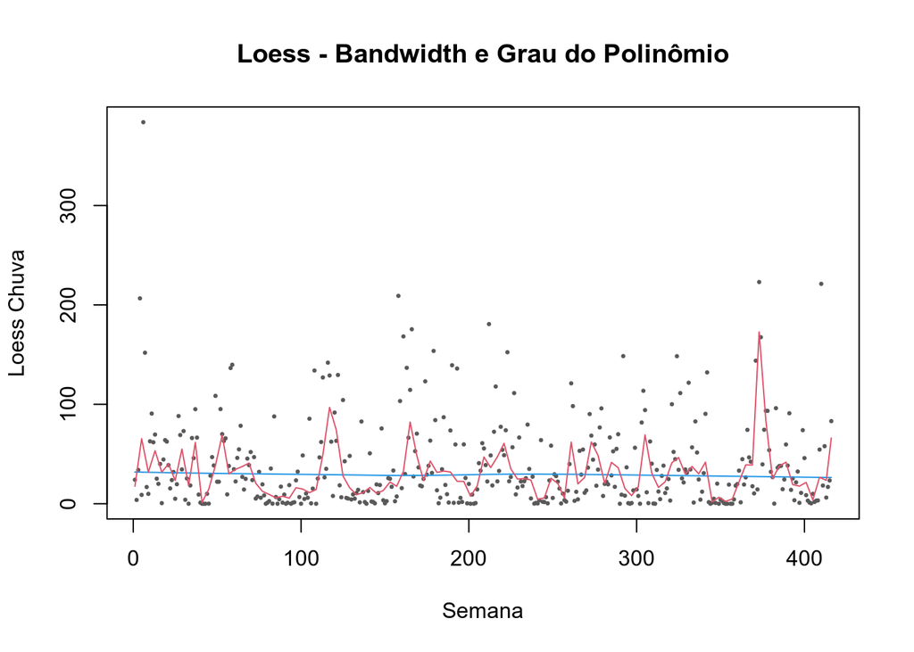

```r
plot(lepto$week, lepto$totrain,cex=.3, pch=19, col="gray35",ylab="Loess Chuva", xlab="Semana", main="Loess - Bandwidth e Grau do Polinômio")
lines(lowess(lepto$totrain ~ lepto$week ,f = 0.75),col=4)
lines(lowess(lepto$totrain ~ lepto$week ,f = 0.015),col=2)
```

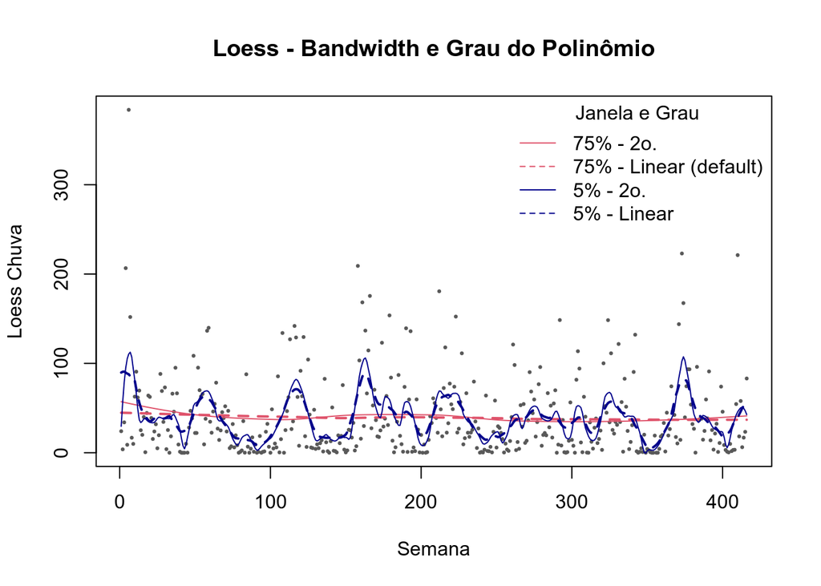

```r
# Loess – Span & Grau
plot(lepto$week, lepto$totrain,cex=.3, pch=19, col="gray35",ylab="Loess Chuva", xlab="Semana", main="Loess - Bandwidth e Grau do Polinômio")
lines(predict(loess(totrain ~ week , data=lepto,span = 0.75, degree = 2)),col=2)
lines(predict(loess(totrain ~ week , data=lepto,span = 0.75, degree = 1)),col=2,lwd=2,lty=2)
lines(predict(loess(totrain ~ week , data=lepto,span = 0.05, degree = 2)),col="darkblue")
lines(predict(loess(totrain ~ week , data=lepto,span = 0.05, degree = 1)),col="darkblue",lwd=2,lty=2)
legend("topright",c("75% - 2o.","75% - Linear (default)","5% - 2o.","5% - Linear"),lty=c(1,2,1,2), col=c(2,2,"darkblue","darkblue"), title="Janela e Grau",bty="n")
```

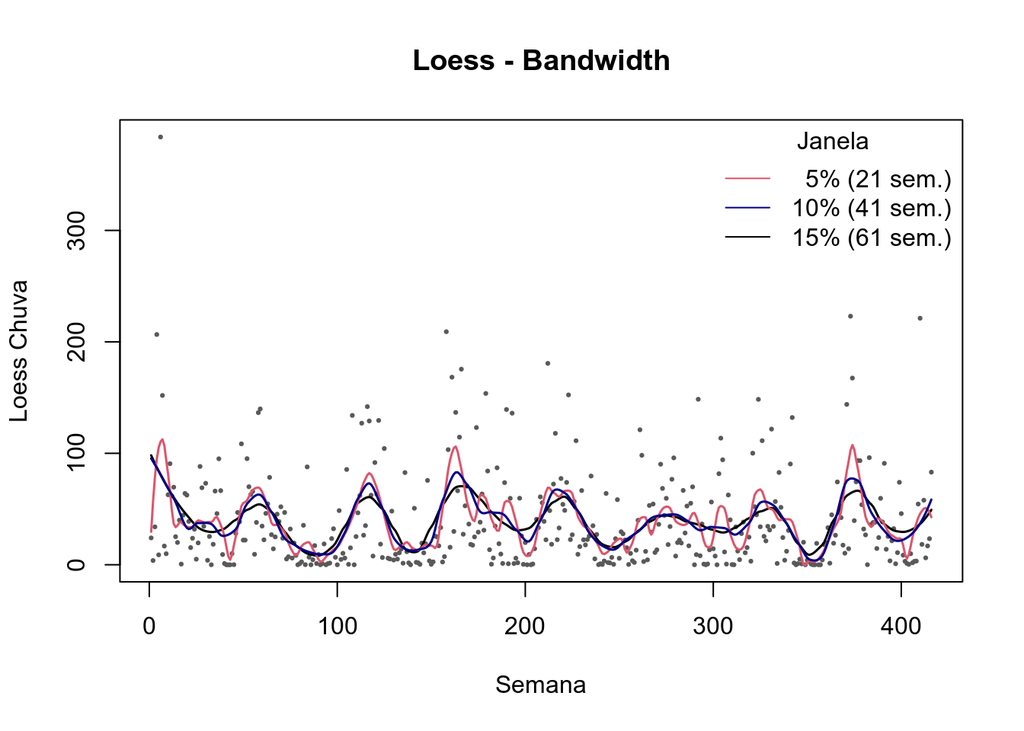

```r
# Loess – Span
# lowess - f
plot(lepto$week, lepto$totrain,cex=.3, pch=19, col="gray35",ylab="Loess Chuva", xlab="Semana", main="Loess - Bandwidth")
lines(predict(loess(totrain ~ week , data=lepto,span = 0.15, degree = 2)),col=1, lwd=1.5)
lines(predict(loess(totrain ~ week , data=lepto,span = 0.05, degree = 2)),col=2, lwd=1.5)
lines(predict(loess(totrain ~ week , data=lepto,span = 0.10, degree = 2)),col="darkblue", lwd=1.5)
legend("topright",c("  5% (21 sem.)","10% (41 sem.)","15% (61 sem.)"),col=c(2,"darkblue",1), lty=c(1,1,1),title="Janela",bty="n")
```

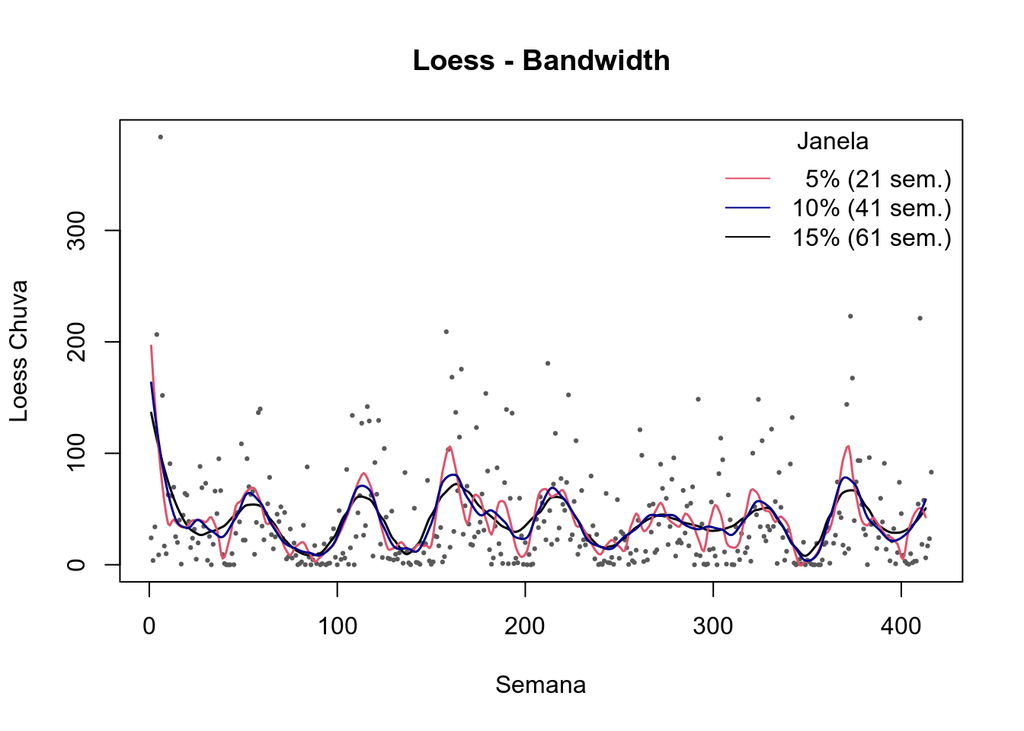

```r
# Loess – Span & Borda
plot(lepto$week, lepto$totrain,cex=.3, pch=19, col="gray35",ylab="Loess Chuva", xlab="Semana", main="Loess - Bandwidth")
lines(predict(loess(totrain ~ week , data=lepto2,span = 0.15, degree = 2)),col=1, lwd=1.5)
lines(predict(loess(totrain ~ week , data=lepto2,span = 0.05, degree = 2)),col=2, lwd=1.5)
lines(predict(loess(totrain ~ week , data=lepto2,span = 0.10, degree = 2)),col="darkblue", lwd=1.5)
legend("topright",c("  5% (21 sem.)","10% (41 sem.)","15% (61 sem.)"),col=c(2,"darkblue",1), lty=c(1,1,1),title="Janela",bty="n")
```

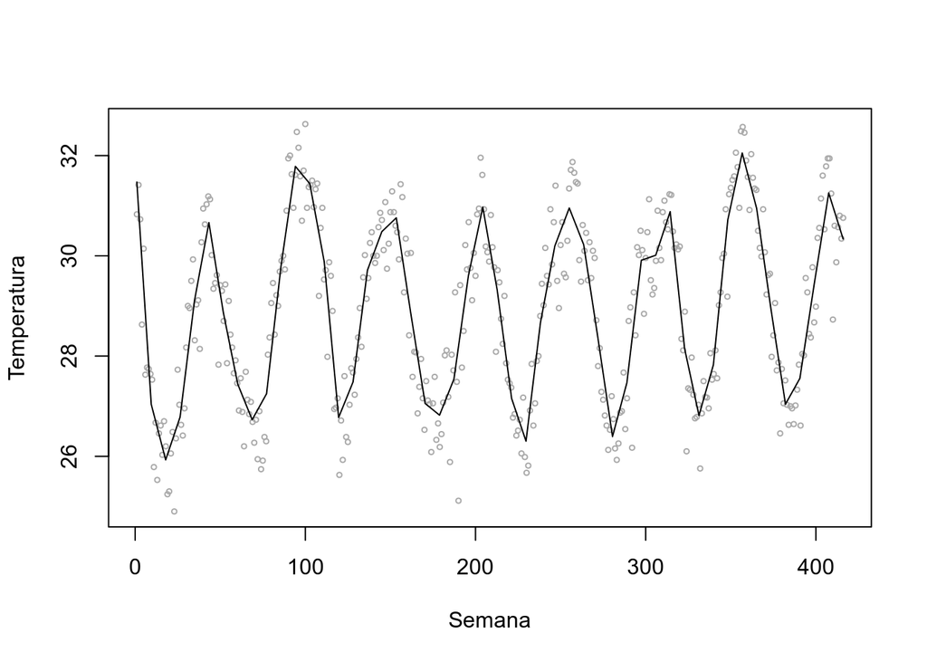

```r
# Loess – Outra forma, mas fica pouco suave
scatter.smooth(lepto$week, lepto$tempmed, span = .05, degree = 2, family =  "gaussian",
               col= "darkgray", cex=.5, ylab="Temperatura", xlab="Semana")
```

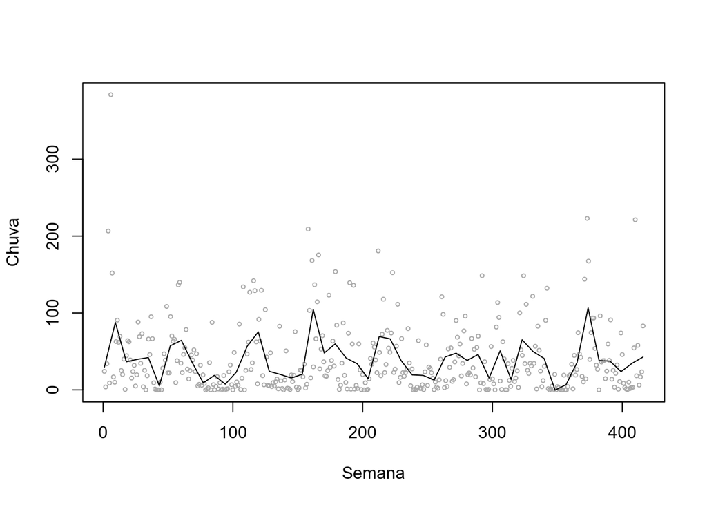

```r
scatter.smooth(lepto$week, lepto$totrain, span = .05, degree = 2, family =  "gaussian",
               col= "darkgray", cex=.5, ylab="Chuva", xlab="Semana")
```

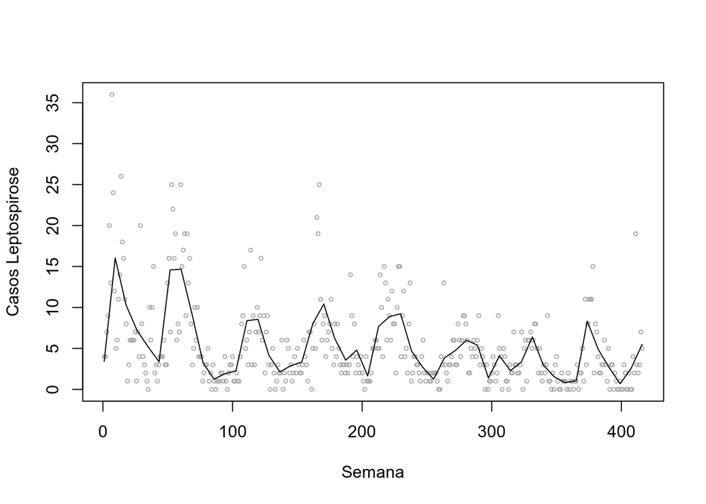

```r
scatter.smooth(lepto$week, lepto$cases, span = .05, degree = 2, family =  "gaussian",
               col= "darkgray", cex=.5, ylab="Casos Leptospirose", xlab="Semana")
```

### Utilização do Lowess

- Vantagens: simples ótimo para análise exploratória.
- Desvantagens: sensı́vel a valores extremos.
- Menos sensı́vel à borda.

### Comparando

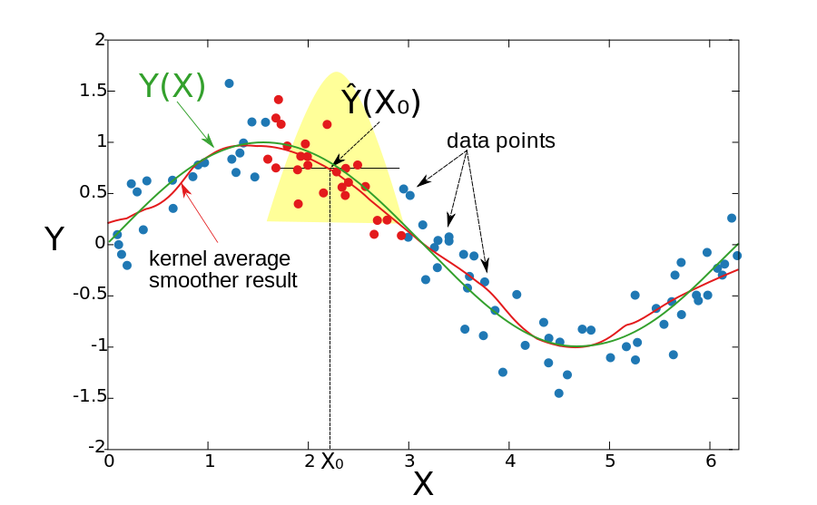

Kernel average smoother

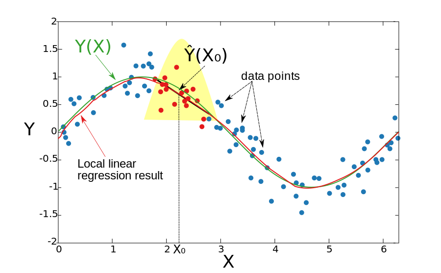

Local linear regression

## Splines

- Splines são funções polinomiais que juntam nos nós, de forma suave, o que é garantido pela existência de $1^a$ e $2^a$ derivadas.
- A escolha do parâmetro de suavização pode ser visual ou mais formal, quando a definição é dada pelo valor que minimiza o erro quadrático médio do ajuste, ou através de alguma forma de validação cruzada.
- A função que minimiza regressão penalizada é uma *spline cúbica natural* com nós em valores distintos de $x_i$.
- Um problema de regressão penalizada: como encontrar a solução $\hat{f}(x)$ que minimize:

$$\sum\left[y_i - f(x_i) \right]^2 + \tau \int f''(x)]^2 dx$$
sendo $\tau$ o parâmetro de alizamento:

- Se $\tau = 0 \Rightarrow \hat{f}(x)$ é interpolação simples
- Se $\tau$ é muito grande $\Rightarrow \hat{f}(x)$ será tal que $f''(x)$ seja zero em todos os pontos, ou seja, mínimos quadrados.

### Splines *vs* Loess

- Como no spline se minimiza uma função-objetivo explı́cita, é mais elegante matematicamente.
- O ajuste dos dois é muito semelhante para o mesmo número de graus de liberdade.
- Pode-se ajustar essas funções para diversos preditores:

$$\eta = \beta_0 + f_1(x_{i1},x_{i2},\ldots,x_{ip}) + \ldots$$
mais complexo para splines (thin plate splines)

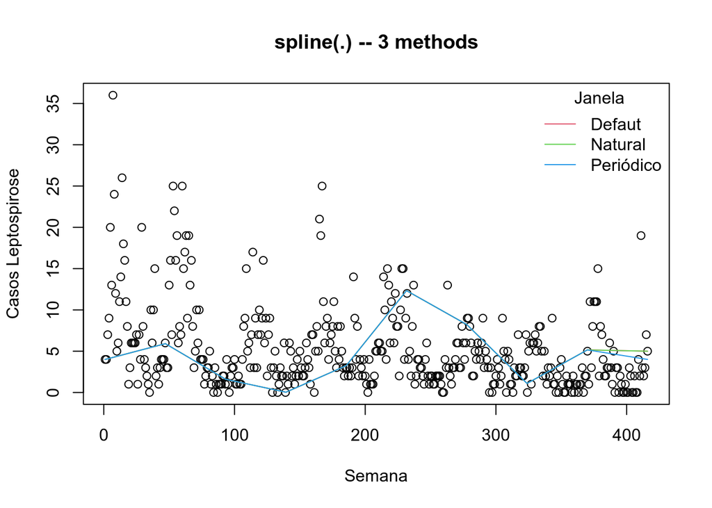

```r
plot(lepto$week, lepto$cases, ylab="Casos Leptospirose", xlab="Semana", main = "spline(.) -- 3 methods")
lines(spline(lepto$week, lepto$cases, n=10 ), col = 2)
lines(spline(lepto$week, lepto$cases, n=10, method = "natural"), col = 3)
lines(spline(lepto$week, lepto$cases, n=10, method = "periodic"), col = 4)
legend("topright",c("Defaut","Natural","Periódico"),col=c(2,3,4), lty=c(1,1,1),title="Janela",bty="n")
```

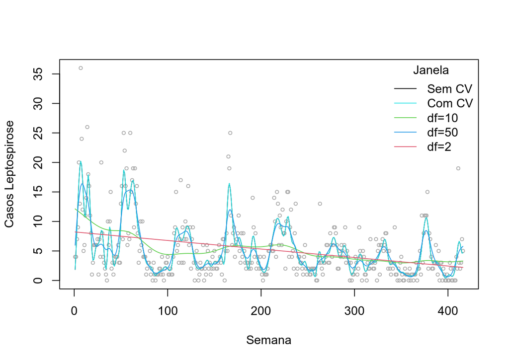

```r
lepto.spl <- smooth.spline(lepto$week, lepto$cases)
lepto.spl.cv <- smooth.spline(lepto$week, lepto$cases, cv =T)
plot(lepto$week, lepto$cases, cex=.6, col="darkgray", ylab="Casos Leptospirose", xlab="Semana")
lines(lepto.spl, col=1)
lines(lepto.spl.cv, col=5)
lines(smooth.spline(lepto$week, lepto$cases, df=10),col=3)
lines(smooth.spline(lepto$week, lepto$cases, df=50),col=4)
lines(smooth.spline(lepto$week, lepto$cases, df=2),col=2)
legend("topright",c("Sem CV","Com CV","df=10", "df=50", "df=2"),col=c(1,5,3,4,2), lty=c(1,1,1),title="Janela",bty="n")
```

## Exercícios Propostos

1. Seja $Z_t$ [*(temperaturaNY.csv)*](https://gitlab.procc.fiocruz.br/oswaldo/eco2019/raw/master/dados/temperaturaNY.csv) uma série temporal referente às médias anuais das temperaturas na cidade de Nova York durante os anos de 1912 e 1971. Utilize e discuta alguns métodos de transformação e/ou suavização para descrever a série.
2. Faça o mesmo com a série de dengue no Vietnã [*(denguecases2.csv)*](https://gitlab.procc.fiocruz.br/oswaldo/eco2019/raw/master/dados/denguecases2.csv)

Verifique as series com atenção e veja como será a melhor maneira de ler e transformar o dato em ST lembre-se que no windows você vai precisar

```r
options(url.method="libcurl")
scan.win <- function(x) {scan(url(x,method = 'libcurl'))}
```

## Bibliografia sugerida

Faraway, J.J. Extending the Linear Model with R. Chapman & Hall/CRC Texts in Statistical Science Series, 2006.

Hastie, T.; Tibshirani, R. Generalised Additive Models. Chapman & Hall, 1990.

Wood, S.N. Generalized Additive Models: An Introduction with R. Chapman & Hall/CRC Texts in Statistical Science Series, 2006.

Venables, W.N. & Ripley, B.D. Modern Applied Statistics with S. (MASS) Fourth Edition 2002